# Tidying & Visualizing Data

### 3.1.2 Global Aesthetic Mapping

That looks pretty good, but this code is getting inefficient, because we’re specifying the x and y axis for each `geom_*` call. Instead, we can use *global* aesthetic mappings, which are specified in the `ggplot()` call. Global mappings are inherited by each layer unless they’re overwritten.

Let’s re-make our plot using global aesthetic mapping:

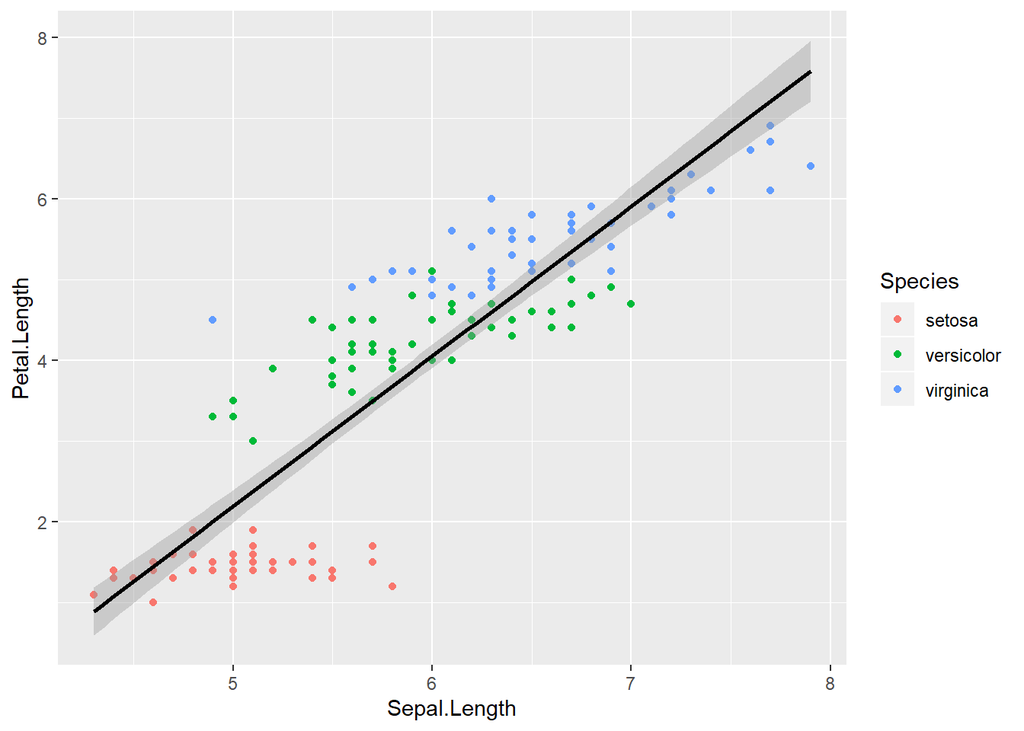

```r
ggplot(data = iris, aes(x = Sepal.Length, y = Petal.Length)) +
  geom_point(aes(color = Species)) +
  geom_smooth(color = "black", method = "lm")
```

You might be wondering, what do we put in global aesthetic mapping and what do we put in the aesthetic mapping of specific geoms? Basically, you want to put anything in the global mapping that you want *every layer to inherit* or at least the majority of them. In the above, I defined x and y globally, because I want those the same in every geom. I didn’t with color, since I wanted a single black line for the smooth line. Let’s take a look at it with color in the global aesthetic:

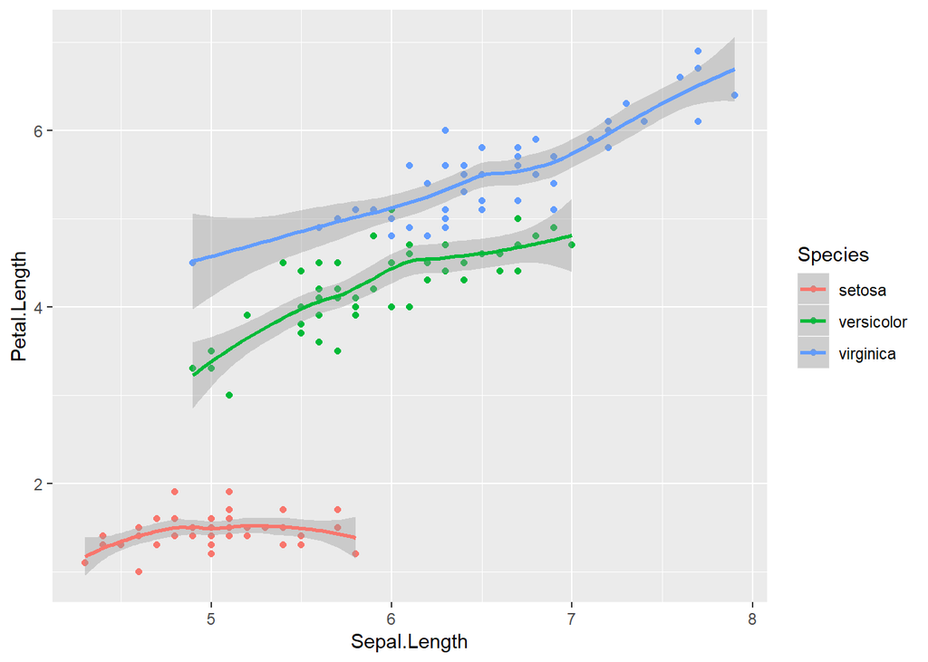

```r
ggplot(data = iris, aes(x = Sepal.Length, y = Petal.Length, color = Species)) +
  geom_point() +
  geom_smooth()
```

As you can see, global aesthetic mapping gets *inherited* by every layer. We *can* override this by providing a different aesthetic mapping in the `geom()` call

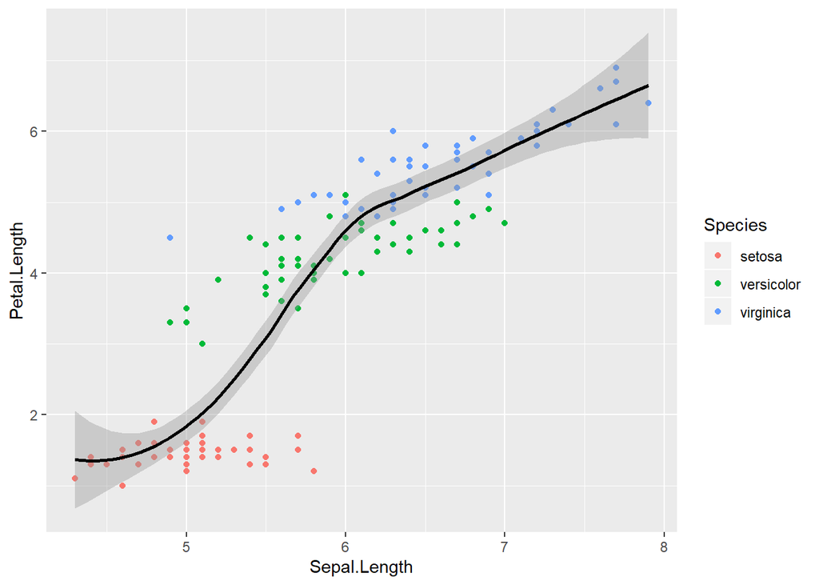

```r
ggplot(data = iris, aes(x = Sepal.Length, y = Petal.Length, color = Species)) +
  geom_point() +
  geom_smooth(color = "black")
```

And, you can sort of mix and match. For example, if you want a smooth line for each species and a general one, you can just make 2 `geom_smooth()` calls, and provide different aesthetic mappings

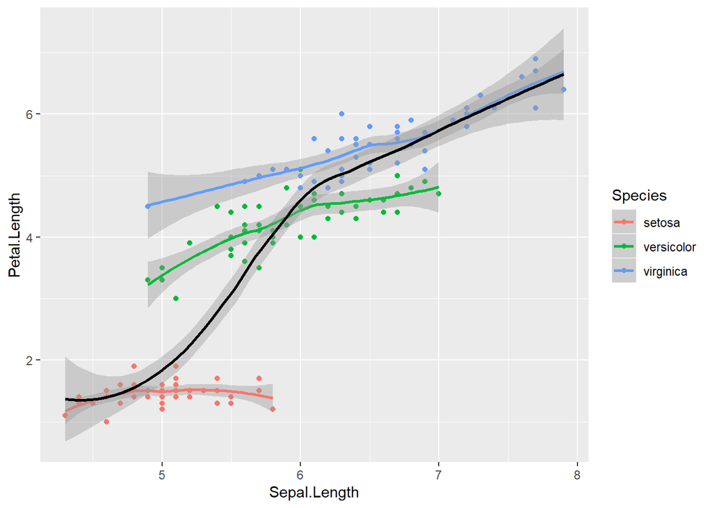

```r
ggplot(data = iris, aes(x = Sepal.Length, y = Petal.Length, color = Species)) +
  geom_point() + # inhereit global
  geom_smooth() + # inherit global
  geom_smooth(color = "black") # change color to constant
```

```r
ggplot(data = iris, aes(x = Species, y = Petal.Length)) +
  geom_bar() # inhereit global
```

[output not shown]

Hmmm, `stat_count()` must not be used with y aesthetic. What does this mean? Let’s take a look at the help documentation:

```r
?geom_bar
```

The help documentation says that the default is `stat = "count"`, which counts the number of classes. We want `stat = "identity"`, which leaves the data as is. Let’s give it another go:

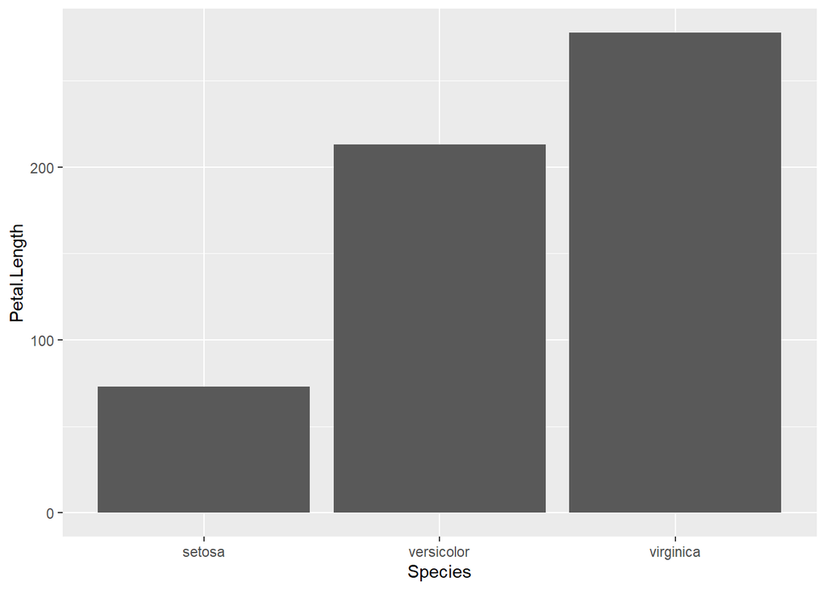

```r
ggplot(data = iris, aes(x = Species, y = Petal.Length)) +
  geom_bar(stat = "identity") # inhereit global
```

And we could add a little color if we wanted:

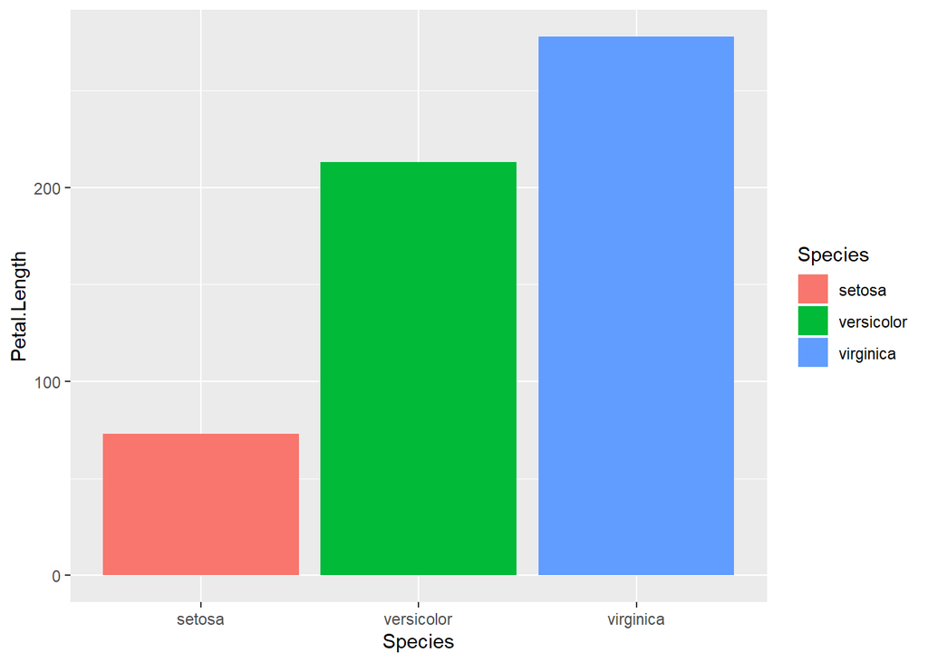

```r
ggplot(data = iris, aes(x = Species, y = Petal.Length, fill = Species)) +
  geom_bar(stat = "identity") # inhereit global
```

### Exercise 3.1b

> I want you to re-create this plot:

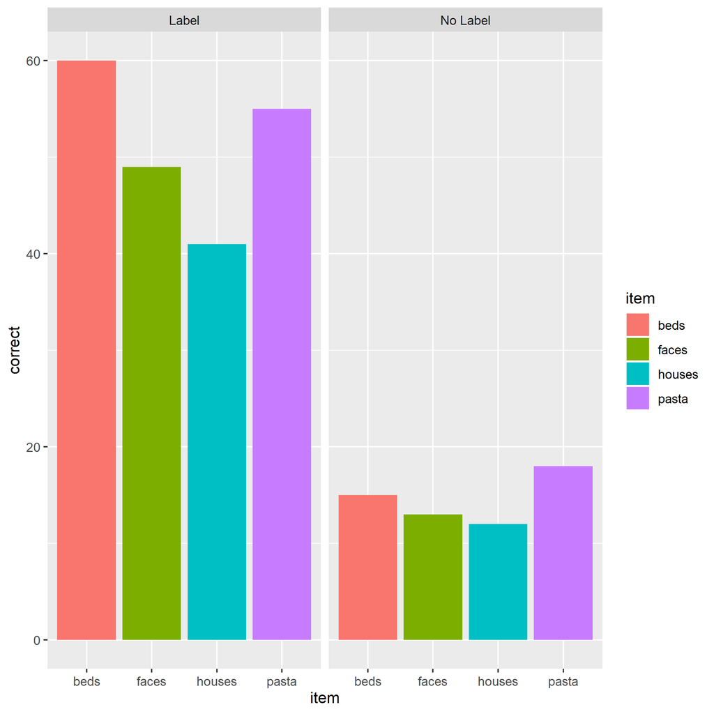

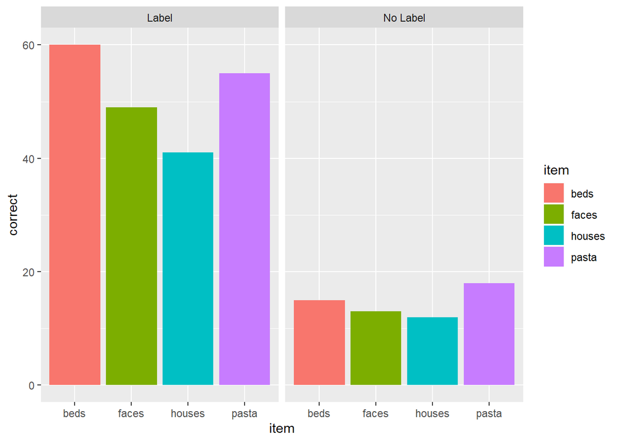

```r
ggplot(ps_data, aes(x = item, y = correct, fill = item)) +
  geom_bar(stat = "identity") +
  facet_wrap(~condition)
```

## 3.2 geom-level Data

So far, we’ve seen that aesthetic mappings can be local to a geom or global and inherited by all geoms by default. In ggplot2, data is the same way. We can have data defined globally in the `ggplot()` call, which is what we’ve been doing so far. Or, we can have it defined within a geom.

For example, if we’re interested in group differences, we may want to include group-level (summary) data and individual data in the same plot. Let’s make a plot of human vs. droid mass, where the average of each group is a bar and individual characters’ data is shown as individual points.

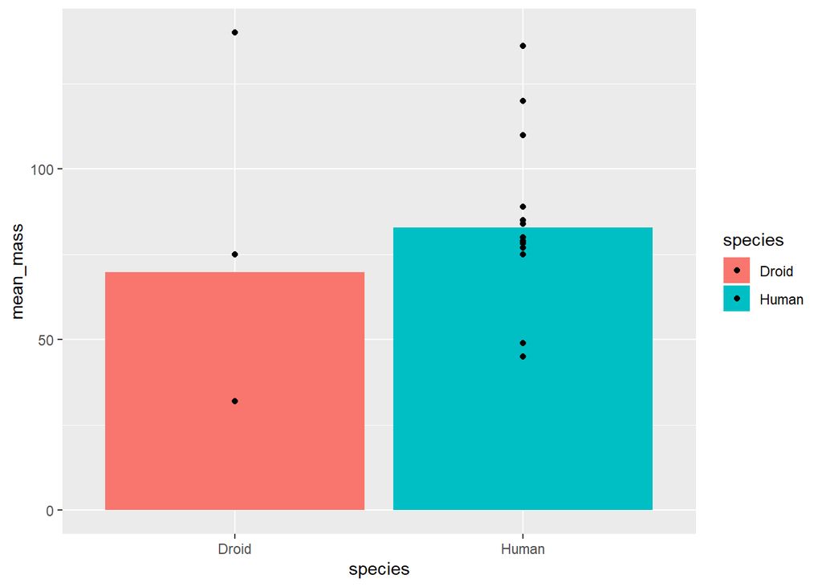

```r
# get summary data
starwars_means <- starwars %>%
  filter(species == "Human" | species == "Droid") %>%
  group_by(species) %>%
  summarize(mean_mass = mean(mass, na.rm = TRUE))

# uisng the summary data as the global data
ggplot(starwars_means, aes(x = species, y = mean_mass, fill = species)) +
  geom_bar(stat = "identity") +
  geom_point(data = filter(starwars, species == "Human" |
                             species == "Droid"), # using individual
                                                  # data as geom specific data
                           aes(x = species, y = mass))
```

This is pretty good, but it’s a little hard to read because points might be overlapping. We have a few options to change the aesthetics to make this plot easier to read.

First, we could artificially add noise to the points so that they don’t overlap using the *jitter* option in the `position` aesthetic. There are multiple ways to do this, but one is to provide the function `position_jitter()` to the `position` argument:

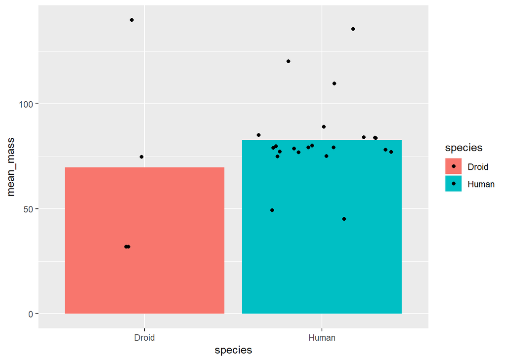

```r
# uisng the summary data as the global data
ggplot(starwars_means, aes(x = species, y = mean_mass, fill = species)) +
  geom_bar(stat = "identity") +
  geom_point(data = filter(starwars, species == "Human" |
                             species == "Droid"), # using individual
                                                  # data as geom specific data
                           aes(x = species, y = mass),
             position = position_jitter())
```

Then, we can add argumnts to `position_jitter()` to customize it more. For example, I just want to points to *jitter* on the x-axis and not the y-axis. That way, they don’t overlap but they still retain their true value of mass. We can do this by setting the `height` argument to 0 within `position_jitter()`. While we’re at it, let’s constrain things a bit more by setting the width argument to a smaller value:

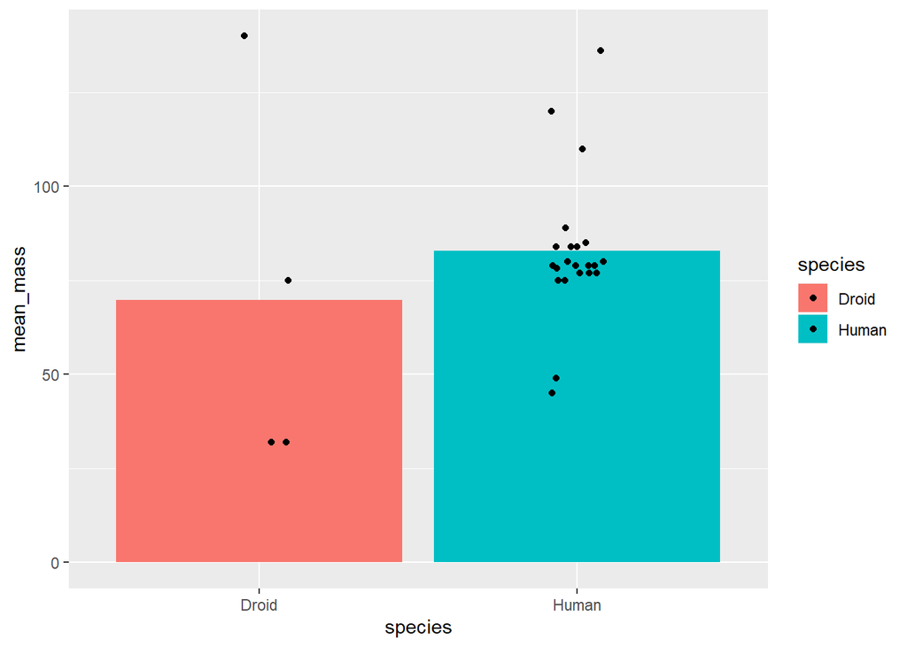

```r
# uisng the summary data as the global data
ggplot(starwars_means, aes(x = species, y = mean_mass, fill = species)) +
  geom_bar(stat = "identity") +
  geom_point(data = filter(starwars, species == "Human" |
                             species == "Droid"), # using individual
                                                  # data as geom specific data
                           aes(x = species, y = mass),
             position = position_jitter(height = 0, width = .1))
```

A second option I want to draw your attention to is the `alpha` aesthetic, which controls the shading of a geom. It defaults to 1, which is full saturation, but you can map it onto data with aesthetic mapping or set it to a constant.

I often do this when I want to keep the position of the data (i.e., not jitter), but want to more easily see overlapping points. To change it, we just set alpha to some number betweeen 0 and 1.

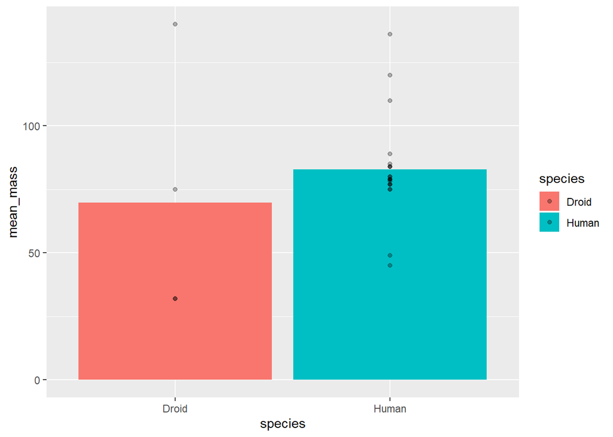

```r
# uisng the summary data as the global data
ggplot(starwars_means, aes(x = species, y = mean_mass, fill = species)) +
  geom_bar(stat = "identity") +
  geom_point(data = filter(starwars, species == "Human" |
                             species == "Droid"), # using individual
                                                  # data as geom specific data
                           aes(x = species, y = mass),
             alpha = .3)
```

### Exercise 3.2a

> Use what we’ve learned so far to plot the average age of kids in each condition of `ps_data` **and** include each kid’s age (hint: you’ll need to create 2 new datasets; one with averages per condition and one with just individual kids’). Try to make sure you can see each point using either position or alpha.

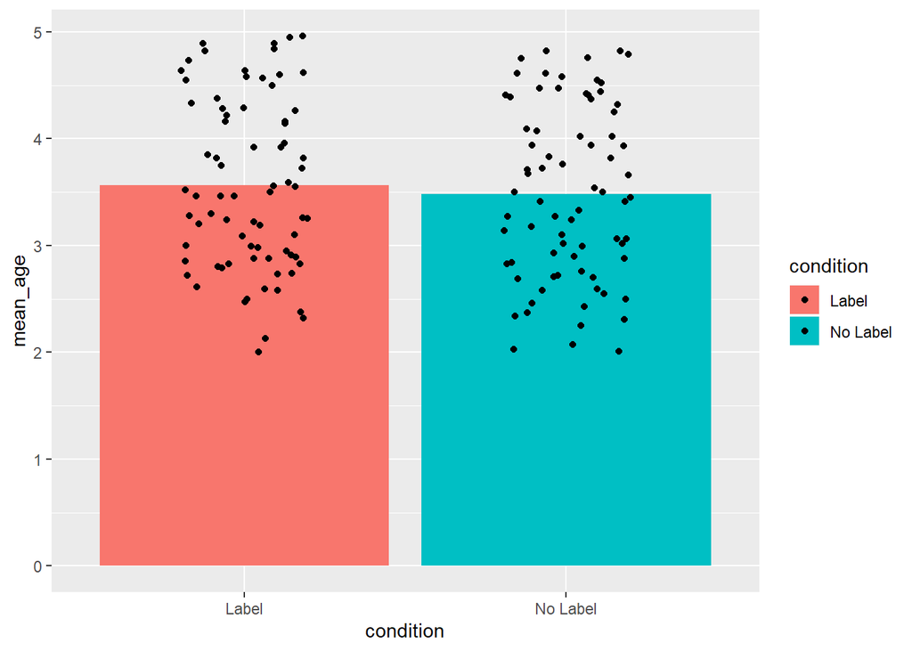

```r
# Mean Data:
ps_mean_age <- ps_data %>%
  group_by(condition) %>%
  summarize(mean_age = mean(age, na.rm = TRUE))

# distinct kids data
ps_distinct_age <- ps_data %>%
  distinct(subid, condition, age)

# jitter option for plot:
ggplot(ps_mean_age, aes(x = condition, y = mean_age, fill = condition)) +
  geom_bar(stat = "identity") +
  geom_point(data = ps_distinct_age, aes(x = condition, y = age),
             position = position_jitter(height = 0, width = .2))
```

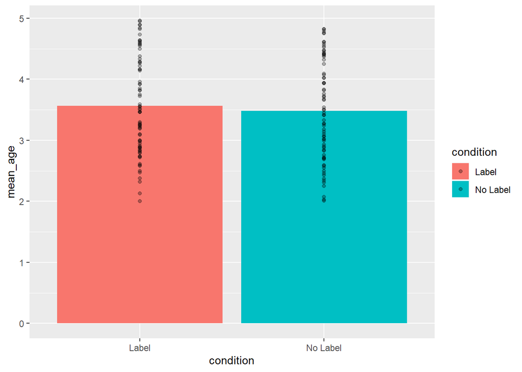

```r
# alpha option for plot:
ggplot(ps_mean_age, aes(x = condition, y = mean_age, fill = condition)) +
  geom_bar(stat = "identity") +
  geom_point(data = ps_distinct_age, aes(x = condition, y = age),
             alpha = .3)
```

## 3.3 Labels & Themes

### 3.3.1 Labels

The plots we just made are pretty close to what we might include in a publication or talk. But, we might want a little more control over things. For example, we might want to change `mean_age` on the Y-axis to a prettier label (e.g., Mean Age). We also might want to add a title. We can do both with the `labs` argument.

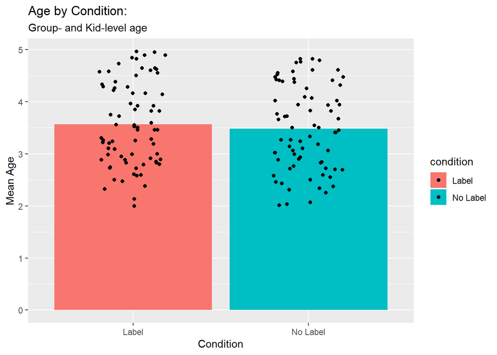

```r
# Mean Data:
ps_mean_age <- ps_data %>%
  group_by(condition) %>%
  summarize(mean_age = mean(age, na.rm = TRUE))

# distinct kids data
ps_distinct_age <- ps_data %>%
  distinct(subid, condition, age)

ggplot(ps_mean_age, aes(x = condition, y = mean_age, fill = condition)) +
  geom_bar(stat = "identity") +
  geom_point(data = ps_distinct_age, aes(x = condition, y = age),
             position = position_jitter(height = 0, width = .2)) +
  # change labels with labs:
  labs(title = "Age by Condition:", # add a title with title
       subtitle = "Group- and Kid-level age", # you can even add a subtitle
       x = "Condition",
       y = "Mean Age")
```

### 3.3.2 Themes

Beautiful! We could also change the way things look by chaging the `theme()`.

#### 3.3.2.1 Customizing `theme()`

You can set arguments within `theme()` manually. For example, let’s change the `axis.text` to be 30 pt size. To do this, we set the `axis.text` argument to a size by setting the size argument of the `element_text()` function.

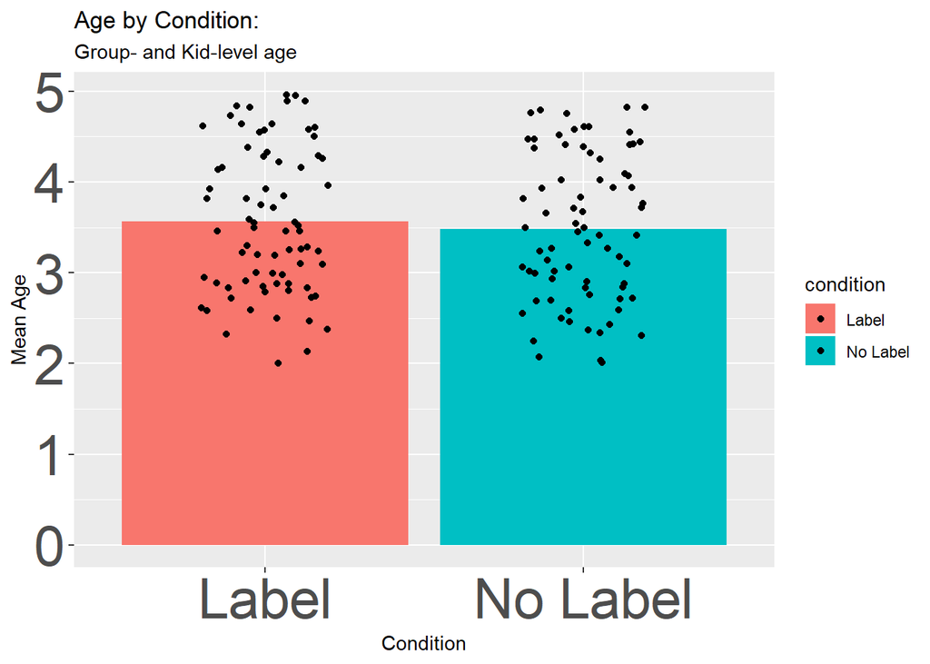

```r
ggplot(ps_mean_age, aes(x = condition, y = mean_age, fill = condition)) +
  geom_bar(stat = "identity") +
  geom_point(data = ps_distinct_age, aes(x = condition, y = age),
             position = position_jitter(height = 0, width = .2)) +
  # change labels with labs:
  labs(title = "Age by Condition:", # add a title with title
       subtitle = "Group- and Kid-level age", # you can even add a subtitle
       x = "Condition",
       y = "Mean Age") +
  theme(axis.text = # axis.title argument of theme
          element_text(size = 30)) # size element of element_text
```

`element_blank()` can be used to remove basically any element. For example, let’s get rid of all of our axis labels:

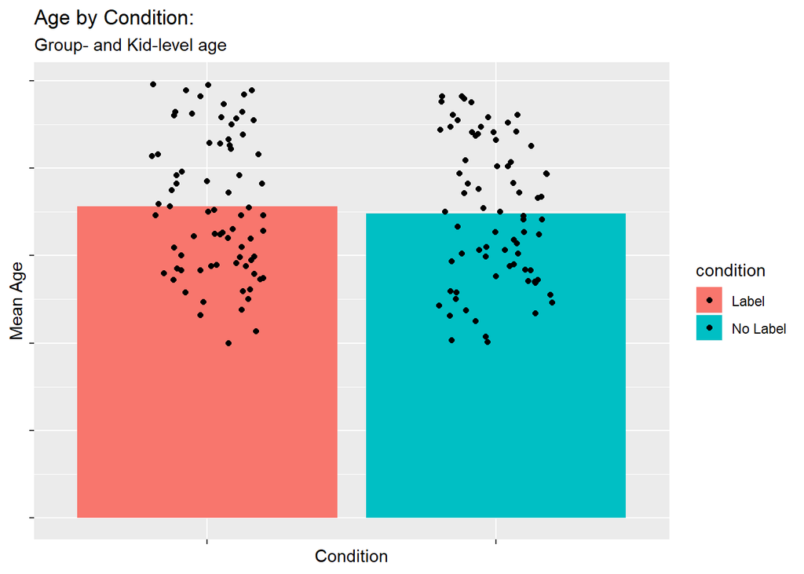

```r
ggplot(ps_mean_age, aes(x = condition, y = mean_age, fill = condition)) +
  geom_bar(stat = "identity") +
  geom_point(data = ps_distinct_age, aes(x = condition, y = age),
             position = position_jitter(height = 0, width = .2)) +
  # change labels with labs:
  labs(title = "Age by Condition:", # add a title with title
       subtitle = "Group- and Kid-level age", # you can even add a subtitle
       x = "Condition",
       y = "Mean Age") +
  theme(axis.text = # axis.title argument of theme
          element_blank()) # set to element_blank
```

You can do **so** much more with customizing themes. And, you can save your theme and use it for other plots too! Let’s save out crazy axis label theme and use it for a couple of plots.

To save a theme, you just assign it to a name like any R object. Let’s do that now:

```r
label_madness_theme <- theme(axis.text = # axis.title argument of theme
          element_text(size = 30)) # size element of element_text
```

And then we just add our custom theme as a layer of our plot:

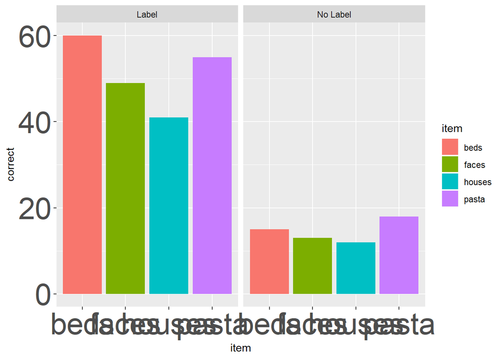

```r
ggplot(ps_data, aes(x = item, y = correct, fill = item)) +
  geom_bar(stat = "identity") +
  facet_wrap(~condition) +
  label_madness_theme # add in the custom theme
```

Ooof, that looks wild. This example is a little silly, buy I use custom themes often to make the same plot scale well for a manuscript (where smaller text & geoms usually work) and PPTs (where larger text & geoms are usually better). Here’s an example from my own work:

```r
# Custom theme for the reputation manuscript
theme_rep_manuscript <-  theme(panel.background = element_blank(),
                         panel.grid.major.x = element_line(size=.4, color="gray90"))+
  theme(axis.line.x = element_line(color="black", size = 1),
        axis.line.y = element_line(color="black", size = 1))+
  theme(axis.title = element_text(size = rel(1), color="black"),
        axis.text = element_text(size = rel(1), color="black"))+
  theme(plot.title= element_text(size=rel(1), hjust = .5))

# Custom theme for the reputation manuscript
theme_rep_ppt <-  theme(panel.background = element_blank(),
                         panel.grid.major.x = element_line(size=1, color="gray90"))+
  theme(axis.line.x = element_line(color="black", size = 2),
        axis.line.y = element_line(color="black", size = 2))+
  theme(axis.title = element_text(size = rel(2), color="black"),
        axis.text = element_text(size = rel(2), color="black"))+
  theme(plot.title= element_text(size=rel(2), hjust = .5))
```

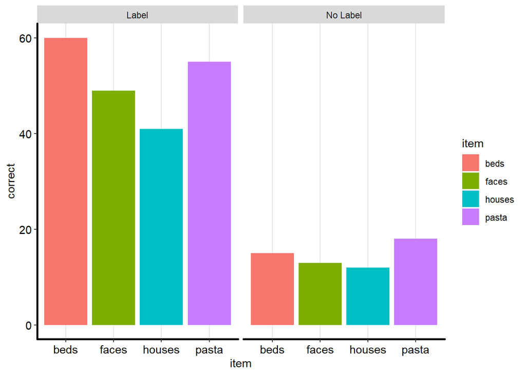

```r
ggplot(ps_data, aes(x = item, y = correct, fill = item)) +
  geom_bar(stat = "identity") +
  facet_wrap(~condition) +
  theme_rep_manuscript
```

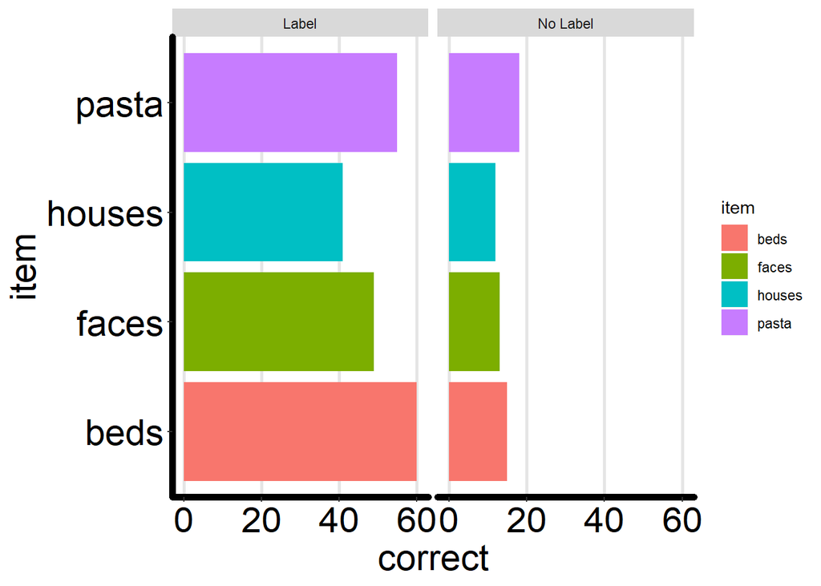

```r
ggplot(ps_data, aes(x = item, y = correct, fill = item)) +
  geom_bar(stat = "identity") +
  facet_wrap(~condition) +
  theme_rep_ppt +
  coord_flip() # flip the coordinates to accomodate size of text
```